# Data Analysis and Statistical Inference Lab 2

Baskaran Viswanathan

September 30, 2015

# Getting Started

```r
load(url("http://www.openintro.org/stat/data/kobe.RData"))

#kobe <- load(url("http://www.openintro.org/stat/data/kobe.RData"))
# Inspect the data

head(kobe)
```

```
##    vs game quarter time
## 1 ORL    1       1 9:47
## 2 ORL    1       1 9:07
## 3 ORL    1       1 8:11
## 4 ORL    1       1 7:41
## 5 ORL    1       1 7:03
## 6 ORL    1       1 6:01
##                                               description basket
## 1                 Kobe Bryant makes 4-foot two point shot      H
## 2                               Kobe Bryant misses jumper      M
## 3                        Kobe Bryant misses 7-foot jumper      M
## 4 Kobe Bryant makes 16-foot jumper (Derek Fisher assists)      H
## 5                         Kobe Bryant makes driving layup      H
## 6                               Kobe Bryant misses jumper      M
```

```r
tail(kobe)
```

```
##      vs game quarter    time                        description basket
## 128 ORL    3       4    3:57  Bryant Jump Shot: Made (28 PTS)        H
## 129 ORL    3       4    3:33        Bryant Layup Shot: Missed        M
## 130 ORL    3       4    2:02          Bryant 3pt Shot: Missed        M
## 131 ORL    3       4 00:23.9          Bryant 3pt Shot: Missed        M
## 132 ORL    3       4 00:06.9          Bryant 3pt Shot: Missed        M
## 133 ORL    3       4 00:00.5 Bryant Layup Shot: Made (31 PTS)        H
```

# Kobe’s track record

In the kobe data frame, every row records a shot taken by Kobe Bryant. If he hit the shot (made a basket), a hit, H, is recorded in the column named basket, otherwise a miss, M, is recorded.

Just looking at the string of hits and misses, it can be difficult to gauge whether or not it seems like Kobe was shooting with a hot hand. One way we can approach this is by considering the belief that hot hand shooters tend to go on shooting streaks. For this lab, we define the length of a shooting streak to be the number of consecutive baskets made until a miss occurs.

For example, in Game 1 Kobe had the following sequence of hits and misses from his nine shot attempts in the first quarter: H M | M | H H M | M | M | M.

```r
# Print the variable names of the data frame.

names(kobe)
```

```
## [1] "vs"          "game"        "quarter"     "time"        "description"
## [6] "basket"
```

# Question 1

What does a streak length of 1 mean, i.e. how many hits and misses are in a streak of 1?

```r
names(kobe)
```

```
## [1] "vs"          "game"        "quarter"     "time"        "description"
## [6] "basket"
```

```r
# Print the first 9 values of the 'basket' variable

kobe$basket[1:9]
```

```
## [1] "H" "M" "M" "H" "H" "M" "M" "M" "M"
```

That’s correct! You can see that within the nine shot attempts, there are six streaks, which are separated by a ‘|’ above. Their lengths are one, zero, two, zero, zero, zero.

Definition: the length of a shooting streak is the number of consecutive baskets (hits) until a miss occurs.

Answer - A hit followed by a miss.

# Question 2

What about a streak length of 0? How many hits and misses are in a streak of 0?

# A first analysis

To start, let’s look at the distribution of the shooting streaks. Along with the data frame, we also loaded the custom function calc_streak into the workspace.

We’ll use this function to calculate the lengths of all shooting streaks and then look at the distribution with a barplot. Note that a bar plot is preferable to a histogram here since our variable is discrete - counts - instead of continuous.

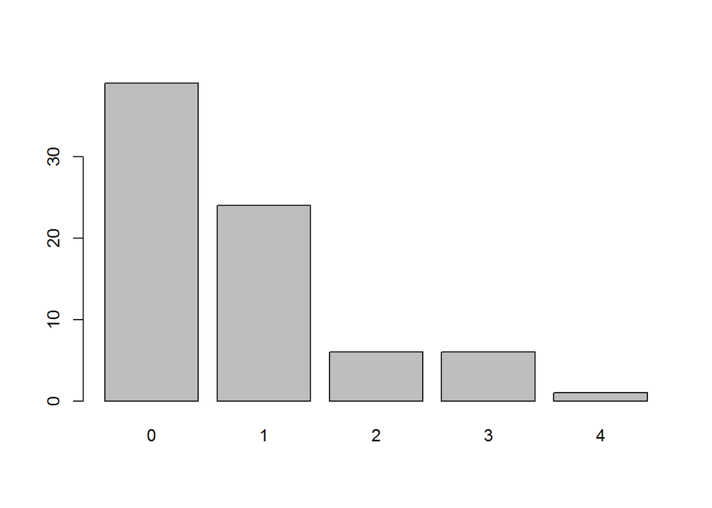

```r
calc_streak = function(x) {
  y <- rep(0, length(x))
  y[x == "H"] <- 1
  y <- c(0, y, 0)
  wz <- which(y == 0)
  streak <- diff(wz) - 1
  return(streak)
}
kobe_streak = calc_streak(kobe$basket)
barplot(table(kobe_streak))
```

# Question 3

Which of the following is false about the distribution of Kobe’s streak lengths from the 2009 NBA finals. Hint: You might want to also use other visualizations and summaries of kobe streak in order to answer this question.

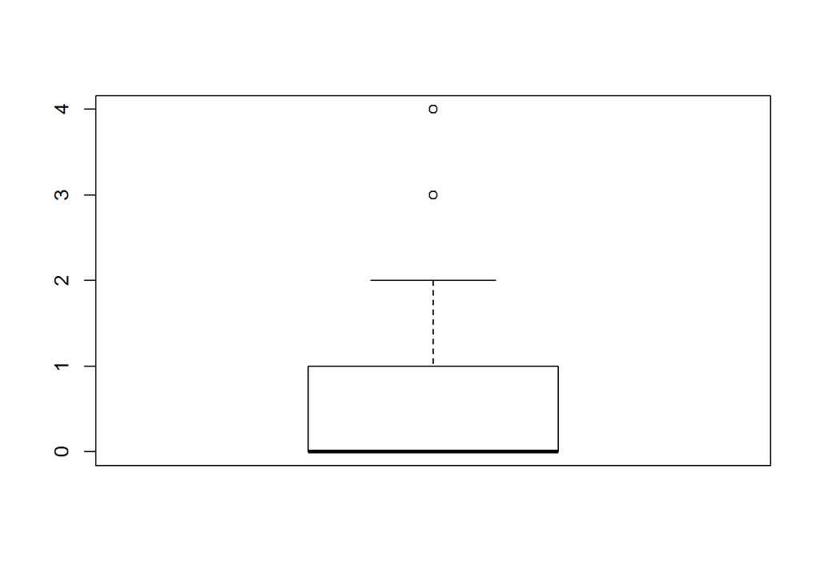

```r
boxplot(kobe_streak)
```

```r
IQR(kobe_streak)
```

```
## [1] 1
```

```r
summary(kobe_streak)
```

```
##    Min. 1st Qu.  Median    Mean 3rd Qu.    Max.
##  0.0000  0.0000  0.0000  0.7632  1.0000  4.0000
```

Answer - The distribution of Kobe’s streaks is unimodal and left skewed.

# Compared to What?

We’ve shown that Kobe had some long shooting streaks, but are they long enough to support the belief that he had hot hands? What can we compare them to?

To answer these questions, let’s return to the idea of independence. Two processes are independent if the outcome of one process doesn’t effect the outcome of the second. If each shot that a player takes is an independent process, having made or missed your first shot will not affect the probability that you will make or miss your second shot.

A shooter with a hot hand will have shots that are not independent of one another. Specifically, if the shooter makes his first shot, the hot hand model says he will have a higher probability of making his second shot.

Let’s suppose for a moment that the hot hand model is valid for Kobe. During his career, the percentage of time Kobe makes a basket (i.e. his shooting percentage) is about 45%, or in probability notation,

P(shot1=H)=0.45

# Question 4

True or False: If Kobe has a hot hand (not independent shots), then the probability that he makes his second shot would go up given that he made the first shot: P(shot 2 = H | shot 1 = H) > 0.45

Answer - TRUE

# Question 5

Exactly, if Kobe has a hot hand, the probability that he makes his second shot would be higher, for example 0.60. As a result of these increased probabilities, you’d expect Kobe to have longer streaks. Compare this to the skeptical perspective where Kobe does not have a hot hand, where each shot is independent of the next. If he hits his first shot, the probability that he makes the second is still 0.45:

P(shot2=H | shot1=H)=0.45

In other words, making the first shot did nothing to effect the probability that he’d make his second shot. If Kobe’s shots are independent, then he’d have the same probability of hitting every shot regardless of his past shots: 45%.

Now that we’ve phrased the situation in terms of independent shots, let’s return to the question: how do we tell if Kobe’s shooting streaks are long enough to indicate that he has hot hands? We can compare his streak lengths to someone without hot hands: an independent shooter. Starting with the next exercise, you’ll learn how to simulate such an independent shooter in R.

If Kobe’s shooting streaks diverge significantly from an independent shooter’s streaks, we can conclude.

```r
outcomes <- c("heads", "tails")
sample(outcomes, size = 1, replace = TRUE)
```

```
## [1] "heads"
```

```r
sim_fair_coin <- sample(outcomes, size = 100, replace = TRUE)
table(sim_fair_coin)
```

```
## sim_fair_coin
## heads tails
##    46    54
```

```r
sim_unfair_coin <- sample(outcomes, size = 100, replace = TRUE, prob = c(0.2, 0.8))
table(sim_unfair_coin)
```

```
## sim_unfair_coin
## heads tails
##    17    83
```

Answer = we can conclude that Kobe likely has a hot hand.

# Question 6

How many heads would expect to come up after flipping this unfair coin 100 times?

Flipping 100 coins If you wanted to simulate flipping a fair coin 100 times, you could either run the function 100 times or, more simply, adjust the size argument, which governs how many samples to draw. Since there are only two elements in outcomes, the probability that we “flip” a coin and it lands heads is 0.5. Suppose again that you have a hat with two slips of paper in it: one slip says “heads” and the other says “tails”. Therefore at each draw, the probability of drawing a chip that says “head” is 50%, and “tail” is 50%. The replace = TRUE argument indicates we put the chip back in the hat before drawing again, therefore always keeping the 50/50 odds.

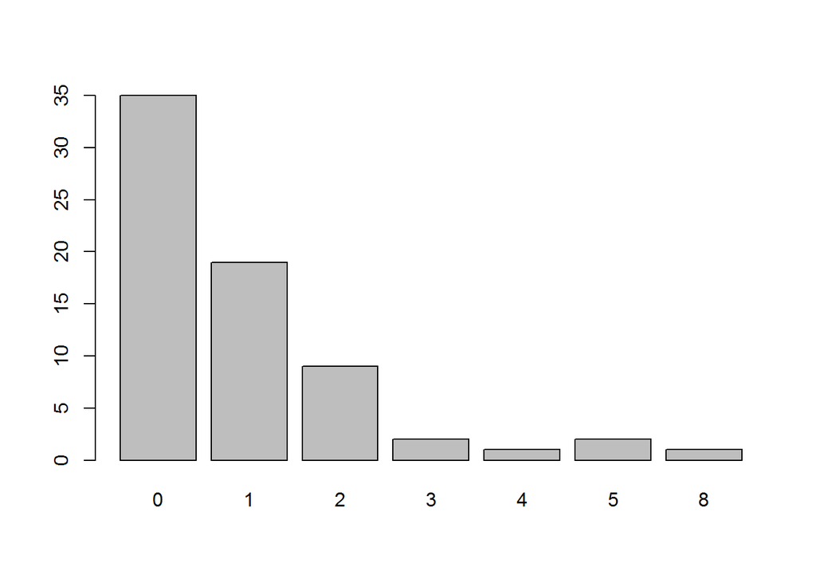

```r
outcomes <- c("H", "M")
sim_basket <- sample(outcomes, size = 133, replace = TRUE, prob = c(0.45, 0.55))
sim_streak <- calc_streak(sim_basket)
barplot(table(sim_streak))
```

```r
summary(sim_streak)
```

```
##    Min. 1st Qu.  Median    Mean 3rd Qu.    Max.
##   0.000   0.000   0.000   0.942   1.000   8.000
```

Answer = 20

# Question 7

If you were to run the simulation of the independent shooter a second time, how would you expect its streak distribution to compare to the distribution from the question above? Answer = A somewhat similar distribution

# Question 8

How does Kobe Bryant’s distribution of streak lengths (kobe streak) compare to the distribution of streak lengths for the simulated shooter?

Answer = They are fairly similar to each other.

# Question 9

True or False: Since Kobe’s streak length distribution looks very similar to the independent shooter’s simulated steak length distrbution, we can conclude that Kobe Bryant likely does not have a “hot hand”.

Answer = TRUE

Questions 10 to 14 should be answered by the individuals.